# Lab 7 - Ten Growth Models - Simple to Advanced

Structural Equation Modeling - Instructor: Karen Nylund-Gibson

Adam Garber

May 17, 2020

`University of California, Santa Barbara`

# Lab preparation

## Creating a version-controlled R-Project with Github

Download repository here: https://github.com/garberadamc/SEM-Lab7

On the Github repository webpage:

1. `fork` your own `branch` of the lab repository
2. copy the repository web URL address from the `clone or download` menu

Within R-Studio:

3. click “NEW PROJECT”
4. choose option `Version Control`
5. choose option `Git`
6. paste the repository web URL path copied from the `clone or download` menu on Github page
7. choose location of the R-Project

## Data source:

All examples utilize the public use dataset, *The Longitudinal Survey of American Youth (LSAY)* [$\color{blue}{\text{See documentation here}}$](https://www.lsay.org/)

Load packages

```r
library(transformr)
library(gganimate)
library(hrbrthemes)
library(tidyverse)
library(haven)
library(janitor)
library(MplusAutomation)
library(rhdf5)
library(here)
library(kableExtra)
library(gtsummary)
library(semPlot)
library(naniar)
```

## `LSAY` data example - `Math Scores` across 6 timepoints

Read in data

```r
lsay_data <- read_spss(here("data", "LSAY_labs.sav")) %>%                    #
  select(RURAL, GENDER, FATHED, MOTHED,                                      #
        -starts_with("AB"),                                                  #
          ends_with("IMP"),                                                  #
          -contains("BIO"),                                                  #
          -contains("PHY")) %>%                                              #
  clean_names() %>%                                                          #
  rename( math_07 = amthimp ,                                                #
          math_08 = cmthimp ,                                                #
          math_09 = emthimp ,                                                #
          math_10 = gmthimp ,                                                #
          math_11 = imthimp ,                                                #
          math_12 = kmthimp ,                                                #
           sci_07 = asciimp ,                                                #
           sci_08 = csciimp ,                                                #
           sci_09 = esciimp ,                                                #
           sci_10 = gsciimp ,                                                #
           sci_11 = isciimp ,                                                #
           sci_12 = ksciimp ) %>%                                            #
  replace_with_na_all(condition = ~.x == 9999.00)                            #
```

View metadeta

```r
sjPlot::view_df(lsay_data)
```

Write a `CSV` file

```r
write_csv(lsay_data, here("data", "lsay_lab7_data.csv"))
```

Read in the `CSV` file (SPSS labels removed)

```r
lsay_lab7 <- read_csv(here("data", "lsay_lab7_data.csv"))
```

# Let’s start modeling

Table. LSAY repeated measures

| Name | Labels | Variable type |
| --- | --- | --- |
| math_07 | 7th grade math score | time varying covariate |
| math_08 | 8th grade math score |  |
| math_09 | 9th grade math score |  |
| math_10 | 10th grade math score |  |
| math_11 | 11th grade math score |  |
| math_12 | 12th grade math score |  |
| sci_07 | 7th grade science score | model indicators (outcomes) |
| sci_08 | 8th grade science score |  |
| sci_09 | 9th grade science score |  |
| sci_10 | 10th grade science score |  |
| sci_11 | 11th grade science score |  |
| sci_12 | 12th grade science score |  |

## Model 01 - `Fixed time effects`

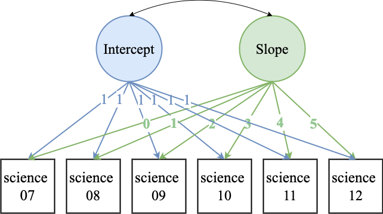

```r
m1_growth  <- mplusObject(
  TITLE = "m01_fixed_time_scores",
  VARIABLE =
    "usevar =
    sci_07-sci_12; ",

  ANALYSIS =
    "estimator = MLR" ,

  MODEL =
   "i s | sci_07@0 sci_08@1 sci_09@2 sci_10@3 sci_11@4 sci_12@5; " ,

  OUTPUT = "sampstat standardized;",

  PLOT = "type=plot3;
          series = sci_07-sci_12(*)",

  usevariables = colnames(lsay_lab7),
  rdata = lsay_lab7)

m1_growth_fit <- mplusModeler(m1_growth,
                     dataout=here("mplus_files", "Lab7.dat"),
                     modelout=here("mplus_files", "m1_growth_Lab7.inp"),
                     check=TRUE, run = TRUE, hashfilename = FALSE)
```

Load in the `mplus.R` functions

```r
source(here("mplus.R.txt"))
```

```
## [1] "Loaded rhdf5 package"
```

Plotting using `gh5` data generated by `Mplus`

1. View plots available for a given model
2. Generate plots using the `get.plot.___` function
3. Extract data and transform to tidy format
4. Plot with `ggplot`

```r
mplus.view.plots(here("mplus_files", "m1_growth_Lab7.gh5"))
```

Prepare plot data

```r
observed <- lsay_lab7 %>% select(starts_with("sci")) %>%
  rownames_to_column() %>% drop_na()

obs100 <- observed[1:100,]

plot_obs <- obs100 %>%
  pivot_longer(`sci_07`:`sci_12`, # The columns I'm gathering together
              names_to = "grade", # new column name for existing names
             values_to = "value") # new column name to store values

gradelevels <- colnames(observed[,2:7])

mean_est <- as.data.frame(mplus.get.estimated_means(here(
  "mplus_files", "m1_growth_Lab7.gh5"))) %>%
  mutate(grade = gradelevels)
```

Plot the model estimated means superimposted on the obserbed individual values

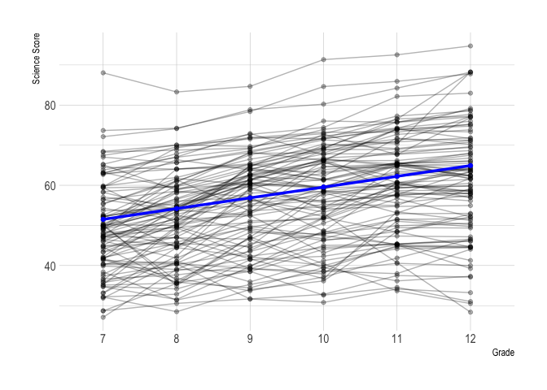

```r
growth_plot <- ggplot() +                                                                   #
  geom_point(data = plot_obs,                                                               #
             aes(x = grade, y = value, group = rowname), alpha = .3) +                      #
  geom_line(data = plot_obs,                                                                #
            aes(x = grade, y = value, group = rowname), alpha = .3) +                       #
  geom_point(data=mean_est,                                                                 #
             aes(x=grade, y = V1), color = "Blue", size = 1.5) +                            #
  geom_line(data=mean_est,                                                                  #
            aes(x=grade, y = V1, group = 1), color = "Blue", size = 1.2) +                  #
  scale_x_discrete(labels = c("7", "8", "9", "10", "11", "12")) +                           #
  labs(x="Grade", y="Science Score") +                                                      #
  theme_ipsum()

growth_plot
```

```r
ggsave(here("figures", "spaghetti_p1.png"), height = 6, width = 8, dpi = "retina")
```

Animate the plot with {`gganimate`}

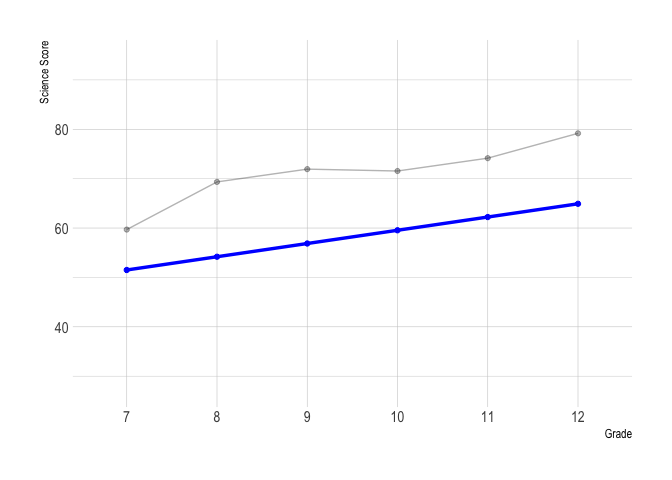

```r
growth_plot +                                                                                #
  transition_states(rowname,                                                                 #
                    transition_length = 1,                                                   #
                    state_length = 1) +                                                      #
  shadow_mark(color = "Magenta", alpha = .3)                                                 #
```

```r
anim_save(here("figures", "spaghetti_plot.gif"), height = 6, width = 8, dpi = "retina")
```

## Model 02 - `Centering the Intercept`

1. Centering determines the interpretation of the intercept growth factor
2. The centering point is the timepoint at which the time score is `zero`
3. A model can be estimated for different centering points depending on which interpretation is of interest

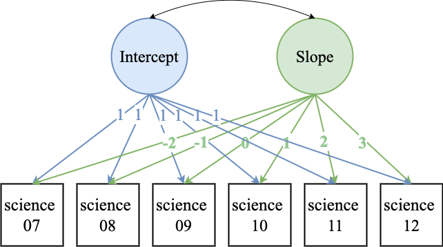

```r
m2_growth  <- mplusObject(
  TITLE = "m02_centering_time_scores",
  VARIABLE =
    "usevar =
    sci_07-sci_12; ",

  ANALYSIS =
    "estimator = MLR" ,

  MODEL =
   "i s | sci_07@-2 sci_08@-1 sci_09@0 sci_10@1 sci_11@2 sci_12@3; " ,

  OUTPUT = "sampstat standardized;",

  PLOT = "type=plot3;
          series = sci_07-sci_12(*)",

  usevariables = colnames(lsay_lab7),
  rdata = lsay_lab7)

m2_growth_fit <- mplusModeler(m2_growth,
                     dataout=here("mplus_files", "Lab7.dat"),
                     modelout=here("mplus_files", "m2_growth_Lab7.inp"),
                     check=TRUE, run = TRUE, hashfilename = FALSE)
```

## Model 03 - `Freely estimated time scores`

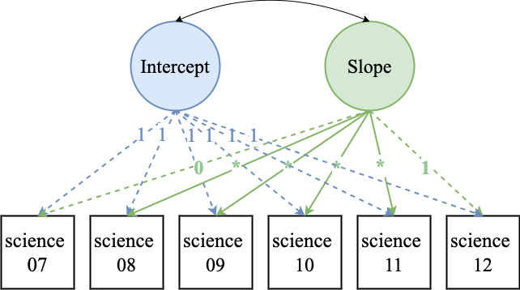

```r
m3_growth  <- mplusObject(
  TITLE = "m03_free_time_scores",
  VARIABLE =
    "usevar =
     sci_07-sci_12; ",

  ANALYSIS =
    "estimator = MLR" ,

  MODEL =
   "i s | sci_07@0 sci_08* sci_09* sci_10* sci_11* sci_12@1; " ,

  OUTPUT = "sampstat standardized;",

  PLOT = "type=plot3;
          series = sci_07-sci_12(*)",

  usevariables = colnames(lsay_lab7),
  rdata = lsay_lab7)

m3_growth_fit <- mplusModeler(m3_growth,
                     dataout=here("mplus_files", "Lab7.dat"),
                     modelout=here("mplus_files", "m3_growth_Lab7.inp"),
                     check=TRUE, run = TRUE, hashfilename = FALSE)
```

Prepare plot data

```r
mean_est2 <- as.data.frame(mplus.get.estimated_means(here("mplus_files", "m3_growth_Lab7.gh5"))) %>%
    mutate(grade = gradelevels)
```

Plot the model estimated means superimposted on the obserbed individual values

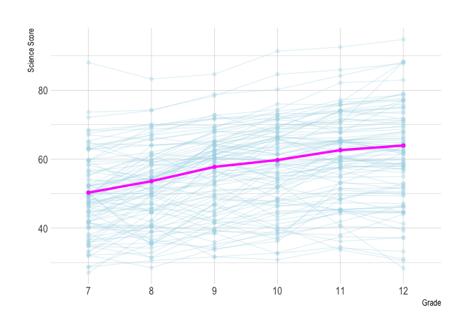

```r
growth_plot <- ggplot() +                                                                             #
  geom_point(data = plot_obs,                                                                         #
             aes(x = grade, y = value, group = rowname), color = "lightblue", alpha = .3) +           #
  geom_line(data = plot_obs,                                                                          #
            aes(x = grade, y = value, group = rowname), color = "lightblue", alpha = .3) +            #
  geom_point(data=mean_est2,                                                                          #
             aes(x=grade, y = V1), color = "magenta", size = 1.5) +                                   #
  geom_line(data=mean_est2,                                                                           #
            aes(x=grade, y = V1, group = 1), color = "magenta", size = 1.2) +                         #
  scale_x_discrete(labels = c("7", "8", "9", "10", "11", "12")) +                                     #
  labs(x="Grade", y="Science Score") +                                                                #
  theme_ipsum()                                                                                       #

growth_plot
```

## Model 04 - `Time-invariant covariates` and `freely estimated time scores`

covariates:

- `gender`: 1 = female
- `rural`: 1 = rural
- `fathed`: Father’s reported education
- `mothed`: Mother’s reported education

```r
m4_growth  <- mplusObject(
  TITLE = "m04_time-inv_covs",
  VARIABLE =
    "usevar =
     sci_07-sci_12
     gender rural fathed mothed; ",

  ANALYSIS =
    "estimator = MLR" ,

  DEFINE =
    "center fathed mothed (grandmean);",

  MODEL =
   "i s | sci_07@0 sci_08* sci_09* sci_10* sci_11* sci_12@1;
    i s on gender rural fathed mothed;" ,



  OUTPUT = "sampstat standardized;",

  PLOT = "type=plot3;
          series = sci_07-sci_12(*)",

  usevariables = colnames(lsay_lab7),
  rdata = lsay_lab7)

m4_growth_fit <- mplusModeler(m4_growth,
                     dataout=here("mplus_files", "Lab7.dat"),
                     modelout=here("mplus_files", "m4_growth_Lab7.inp"),
                     check=TRUE, run = TRUE, hashfilename = FALSE)
```

Check the path diagram with `semPlot`

```r
m4_output <- readModels(here("mplus_files", "m4_growth_Lab7.out"))
```

```
## Reading model:  /Users/agarber/Desktop/SEM_S20/Lab7_SEM/mplus_files/m4_growth_Lab7.out
```

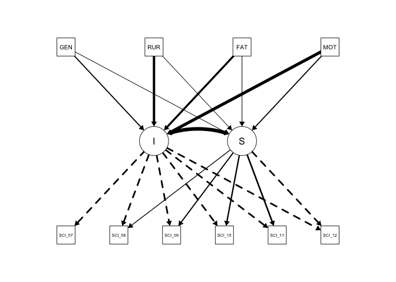

```r
semPaths(m4_output,  "est",                                                             #
         intercepts=FALSE, residuals = FALSE, fade = FALSE,                             #
         edge.color = "black", edgeLabels = "")                                         #
```

## Model 05 - `Time-varying covariates`

repeated measure covariate: `math scores: grades 7 to 12` time-invariant covariate: `mothed`

```r
m5_growth  <- mplusObject(
  TITLE = "m05_time-varying_covs",
  VARIABLE =
    "usevar =
     sci_07-sci_12
     math_07-math_12 mothed; ",

  ANALYSIS =
    "estimator = MLR" ,

  DEFINE =
    "center mothed (grandmean);",

  MODEL =
   "i s | sci_07@0 sci_08* sci_09* sci_10* sci_11* sci_12@1;
    i s on mothed;
    sci_07 on math_07;
    sci_08 on math_08;
    sci_09 on math_09;
    sci_10 on math_10;
    sci_11 on math_11;
    sci_12 on math_12; ",

  OUTPUT = "sampstat standardized;",

  PLOT = "type=plot3;
          series = sci_07-sci_12(*)",

  usevariables = colnames(lsay_lab7),
  rdata = lsay_lab7)

m5_growth_fit <- mplusModeler(m5_growth,
                     dataout=here("mplus_files", "Lab7.dat"),
                     modelout=here("mplus_files", "m5_growth_Lab7.inp"),
                     check=TRUE, run = TRUE, hashfilename = FALSE)
```

Check the path diagram

```r
m5_output <- readModels(here("mplus_files", "m5_growth_Lab7.out"))
```

```
## Reading model:  /Users/agarber/Desktop/SEM_S20/Lab7_SEM/mplus_files/m5_growth_Lab7.out
```

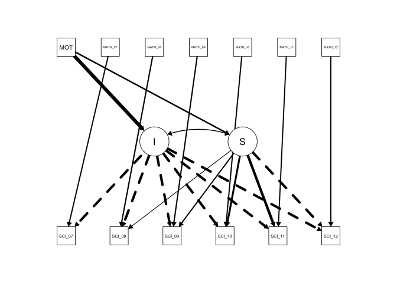

```r
semPaths(m5_output, "est", intercepts = FALSE, residuals = FALSE, fade = FALSE, edge.color = "black",
    edgeLabels = "")
```

______________________________________________

## Model 06 - `Time-varying covariate with time-invariant effect`

```r
m6_growth  <- mplusObject(
  TITLE = "m06_time-varying_covs",
  VARIABLE =
    "usevar =
     sci_07-sci_12
     math_07-math_12 mothed; ",

  ANALYSIS =
    "estimator = MLR" ,

  DEFINE =
    "center mothed (grandmean);",

  MODEL =
   "i s | sci_07@0 sci_08* sci_09* sci_10* sci_11* sci_12@1;
    i s on mothed;
    sci_07 on math_07(1); ! TIME-INVARIANT: Fixed to equality
    sci_08 on math_08(1);
    sci_09 on math_09(1);
    sci_10 on math_10(1);
    sci_11 on math_11(1);
    sci_12 on math_12(1); ",

  OUTPUT = "sampstat standardized;",

  PLOT = "type=plot3;
          series = sci_07-sci_12(*)",

  usevariables = colnames(lsay_lab7),
  rdata = lsay_lab7)

m6_growth_fit <- mplusModeler(m6_growth,
                     dataout=here("mplus_files", "Lab7.dat"),
                     modelout=here("mplus_files", "m6_growth_Lab7.inp"),
                     check=TRUE, run = TRUE, hashfilename = FALSE)
```

## Model 07 - `Quadratic Growth`

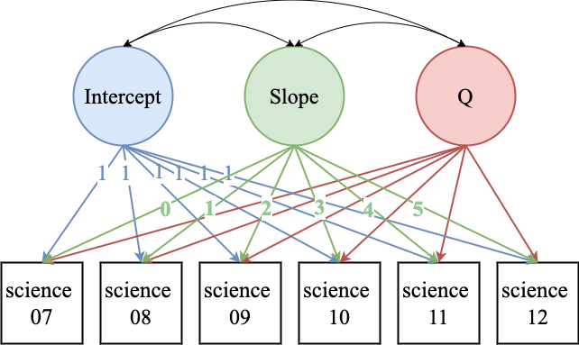

```r
m7_growth  <- mplusObject(
  TITLE = "m07_quadratic",
  VARIABLE =
    "usevar =
     sci_07-sci_12; ",

  ANALYSIS =
    "estimator = MLR" ,

  MODEL =
   "i s q | sci_07@0 sci_08@1 sci_09@2 sci_10@3 sci_11@4 sci_12@5; ",

  OUTPUT = "sampstat standardized tech4;",

  PLOT = "type=plot3;
          series = sci_07-sci_12(*)",

  usevariables = colnames(lsay_lab7),
  rdata = lsay_lab7)

m7_growth_fit <- mplusModeler(m7_growth,
                     dataout=here("mplus_files", "Lab7.dat"),
                     modelout=here("mplus_files", "m7_growth_Lab7.inp"),
                     check=TRUE, run = TRUE, hashfilename = FALSE)
```

## Model 08 - `Parallel Process Growth Model`

[figure not shown]

```r
m8_growth  <- mplusObject(
  TITLE = "m08_parallel_process",
  VARIABLE =
    "usevar =
     sci_07-sci_12
     math_07-math_12 mothed;",

  DEFINE =
    "center mothed (grandmean);",

  ANALYSIS =
    "estimator = MLR" ,

  MODEL =
   "is ss | sci_07@0 sci_08@1 sci_09@2 sci_10@3 sci_11@4 sci_12@5;
    im sm | math_07@0 math_08@1 math_09@2 math_10@3 math_11@4 math_12@5;

    is ss im sm on mothed;  ! time-invariant covariate ",

  OUTPUT = "sampstat standardized;",

  PLOT = "type=plot3;
          series = sci_07-sci_12(*)",

  usevariables = colnames(lsay_lab7),
  rdata = lsay_lab7)

m8_growth_fit <- mplusModeler(m8_growth,
                     dataout=here("mplus_files", "Lab7.dat"),
                     modelout=here("mplus_files", "m8_growth_Lab7.inp"),
                     check=TRUE, run = TRUE, hashfilename = FALSE)
```

## Model 09 - `Piecewise Growth Model (type I)`

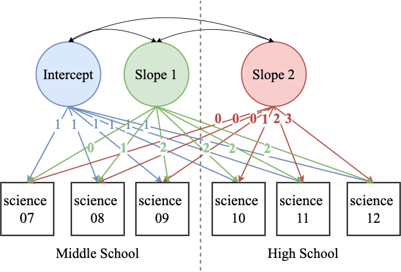

```r
m9_growth  <- mplusObject(
  TITLE = "m09_piecewise_1int_2slopes",
  VARIABLE =
    "usevar =
     sci_07-sci_12 mothed;",

  ANALYSIS =
    "estimator = MLR" ,

  DEFINE =
    "center mothed (grandmean);",

  MODEL =
   "i1 s1 | sci_07@0 sci_08@1 sci_09@2 sci_10@2 sci_11@2 sci_12@2;
      s2 by sci_07@0 sci_08@0 sci_09@0 sci_10@1 sci_11@2 sci_12@3;

    i1 s1 s2 on mothed; ",

  OUTPUT = "sampstat standardized;",

  PLOT = "type=plot3;
          series = sci_07-sci_12(*)",

  usevariables = colnames(lsay_lab7),
  rdata = lsay_lab7)

m9_growth_fit <- mplusModeler(m9_growth,
                     dataout=here("mplus_files", "Lab7.dat"),
                     modelout=here("mplus_files", "m9_growth_Lab7.inp"),
                     check=TRUE, run = TRUE, hashfilename = FALSE)
```

Prepare plot data

```r
mean_est3 <- as.data.frame(mplus.get.estimated_means(here("mplus_files", "m9_growth_Lab7.gh5"))) %>%
    mutate(grade = gradelevels)
```

Plot the model estimated means superimposted on the obserbed individual values

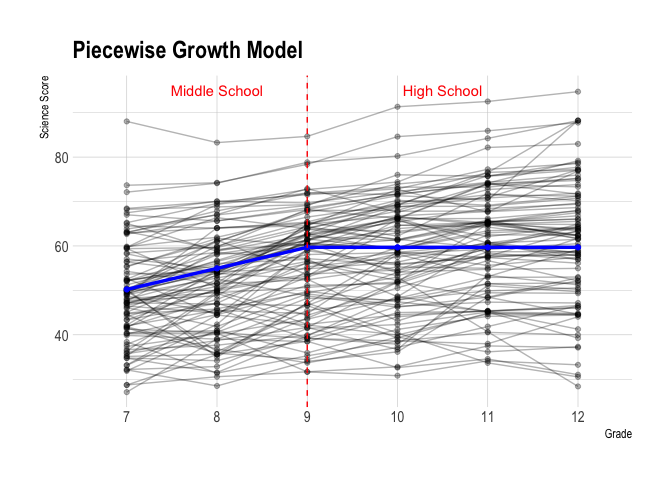

```r
growth_plot <- ggplot() +                                                                   #
  geom_point(data = plot_obs,                                                               #
             aes(x = grade, y = value, group = rowname), alpha = .3) +                      #
  geom_line(data = plot_obs,                                                                #
            aes(x = grade, y = value, group = rowname), alpha = .3) +                       #
  geom_point(data=mean_est3,                                                                #
             aes(x=grade, y = V1), color = "Blue", size = 1.5) +                            #
  geom_line(data=mean_est3,                                                                 #
            aes(x=grade, y = V1, group = 1), color = "Blue", size = 1.2) +
  geom_vline(xintercept=3, linetype="dashed", color = "red") +
  annotate("text", x = 2, y = 95, label = "Middle School", color="red") +
  annotate("text", x = 4.5, y = 95, label = "High School", color="red") +
  scale_x_discrete(labels = c("7", "8", "9", "10", "11", "12")) +                           #
  labs(title= "Piecewise Growth Model", x="Grade", y="Science Score") +                      #
  theme_ipsum()

growth_plot
```

## Model 10 - `Piecewise Growth Model (type II)`

```r
m10_growth  <- mplusObject(
  TITLE = "m10_piecewise_1int_2slopes",
  VARIABLE =
    "usevar =
     sci_07-sci_12 mothed;",

  ANALYSIS =
    "estimator = MLR;" ,

  DEFINE =
    "center mothed (grandmean);",

  MODEL =
   "i1 s1 | sci_07@0 sci_08@1 sci_09@2;
    i2 s2 | sci_10@0 sci_11@1 sci_12@2;

    [s1] (p1);
    [s2] (p2);

    i1 s1 s2 on mothed; ",

  MODELTEST = "p1=p2;  !testing if the two slopes are the same",

  OUTPUT = "sampstat standardized;",

  PLOT = "type=plot3;
          series = sci_07-sci_12(*)",

  usevariables = colnames(lsay_lab7),
  rdata = lsay_lab7)

m10_growth_fit <- mplusModeler(m10_growth,
                     dataout=here("mplus_files", "Lab7.dat"),
                     modelout=here("mplus_files", "m10_growth_Lab7.inp"),
                     check=TRUE, run = TRUE, hashfilename = FALSE)
```

Check the path diagram

```r
m10_output <- readModels(here("mplus_files", "m10_growth_Lab7.out"))
```

```
## Reading model:  /Users/agarber/Desktop/SEM_S20/Lab7_SEM/mplus_files/m10_growth_Lab7.out
```

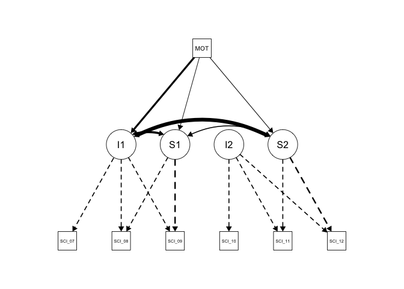

```r
semPaths(m10_output, "est", intercepts = FALSE, residuals = FALSE, fade = FALSE,
    edge.color = "black", edgeLabels = "")
```

Compare model fit across 10 models

```r
all_models <- readModels(here("mplus_files"))
```

```
## Reading model:  /Users/agarber/Desktop/SEM_S20/Lab7_SEM/mplus_files/m1_growth_Lab7.out
## Reading model:  /Users/agarber/Desktop/SEM_S20/Lab7_SEM/mplus_files/m10_growth_Lab7.out
## Reading model:  /Users/agarber/Desktop/SEM_S20/Lab7_SEM/mplus_files/m2_growth_Lab7.out
## Reading model:  /Users/agarber/Desktop/SEM_S20/Lab7_SEM/mplus_files/m3_growth_Lab7.out
## Reading model:  /Users/agarber/Desktop/SEM_S20/Lab7_SEM/mplus_files/m4_growth_Lab7.out
## Reading model:  /Users/agarber/Desktop/SEM_S20/Lab7_SEM/mplus_files/m5_growth_Lab7.out
## Reading model:  /Users/agarber/Desktop/SEM_S20/Lab7_SEM/mplus_files/m6_growth_Lab7.out
## Reading model:  /Users/agarber/Desktop/SEM_S20/Lab7_SEM/mplus_files/m7_growth_Lab7.out
## Reading model:  /Users/agarber/Desktop/SEM_S20/Lab7_SEM/mplus_files/m8_growth_Lab7.out
## Reading model:  /Users/agarber/Desktop/SEM_S20/Lab7_SEM/mplus_files/m9_growth_Lab7.out
```

```r
summary_fit <- LatexSummaryTable(all_models, keepCols = c("Title", "Parameters",
    "ChiSqM_Value", "CFI", "TLI", "SRMR", "RMSEA_Estimate", "RMSEA_90CI_LB", "RMSEA_90CI_UB"),
    sortBy = "Title")
```

# `Model fit summary`

Make a table with `gt::gt()`

```r
library(gt)

fit_table <- summary_fit %>%
  gt() %>%
  tab_header(
    title = "Fit Indices",  # Add a title
    subtitle = ""           # And a subtitle
  ) %>%
  tab_options(
    table.width = pct(80)
  ) %>%
  tab_footnote(
    footnote = "Longitudinal Survey American Youth (LSAY)",
    location = cells_title())

fit_table
```

Fit Indices<sup>1</sup>

| Title | Parameters | ChiSqM_Value | CFI | TLI | SRMR | RMSEA_Estimate | RMSEA_90CI_LB | RMSEA_90CI_UB |
| --- | --- | --- | --- | --- | --- | --- | --- | --- |
| m01_fixed_time_scores | 11 | 1064.490 | 0.938 | 0.942 | 0.076 | 0.106 | 0.100 | 0.111 |
| m02_centering_time_scores | 11 | 1064.492 | 0.938 | 0.942 | 0.076 | 0.106 | 0.100 | 0.111 |
| m03_free_time_scores | 15 | 408.801 | 0.977 | 0.971 | 0.063 | 0.075 | 0.069 | 0.081 |
| m04_time-inv_covs | 23 | 464.948 | 0.971 | 0.960 | 0.041 | 0.075 | 0.069 | 0.081 |
| m05_time-varying_covs | 23 | 1398.808 | 0.906 | 0.884 | 0.338 | 0.127 | 0.121 | 0.132 |
| m06_time-varying_covs | 18 | 1540.135 | 0.897 | 0.884 | 0.340 | 0.126 | 0.121 | 0.132 |
| m07_quadratic | 15 | 226.244 | 0.987 | 0.984 | 0.036 | 0.055 | 0.049 | 0.062 |
| m08_parallel_process | 30 | 3138.892 | 0.936 | 0.930 | 0.061 | 0.086 | 0.083 | 0.089 |
| m09_piecewise_1int_2slopes | 17 | 2405.521 | 0.876 | 0.837 | 0.180 | 0.161 | 0.156 | 0.167 |
| m10_piecewise_1int_2slopes | 20 | 3806.656 | 0.803 | 0.682 | 0.397 | 0.226 | 0.220 | 0.232 |

<sup>*1*</sup> Longitudinal Survey American Youth (LSAY)

# References

Hallquist, M. N., & Wiley, J. F. (2018). MplusAutomation: An R Package for Facilitating Large-Scale Latent Variable Analyses in Mplus. Structural equation modeling: a multidisciplinary journal, 25(4), 621-638.

Miller, J. D., Hoffer, T., Suchner, R., Brown, K., & Nelson, C. (1992). LSAY codebook. Northern Illinois University.

Muthén, B. O., Muthén, L. K., & Asparouhov, T. (2017). Regression and mediation analysis using Mplus. Los Angeles, CA: Muthén & Muthén.

Muthén, L.K. and Muthén, B.O. (1998-2017). Mplus User’s Guide. Eighth Edition. Los Angeles, CA: Muthén & Muthén

R Core Team (2017). R: A language and environment for statistical computing. R Foundation for Statistical Computing, Vienna, Austria. URL http://www.R-project.org/

Wickham et al., (2019). Welcome to the tidyverse. Journal of Open Source Software, 4(43), 1686, https://doi.org/10.21105/joss.01686